# Lecture 8 Moving average invertibility and autoregressive approximation

$$\large{\textbf{Autoregressive approximation}}$$

## AR vs (AR)MA models

- Specification search is simpler in one (*p*) than two (*p*,*q*) dimensions.
- AR can be estimated by OLS  
  MA requires numerical search
- AR models are easier to extend to models of multiple time series.

(There are not huge problems for MA.)

## Interest rate forecasts

In Tutorial 8 we construct forecasting models for first differences of 3 month Bank Accepted Bills.

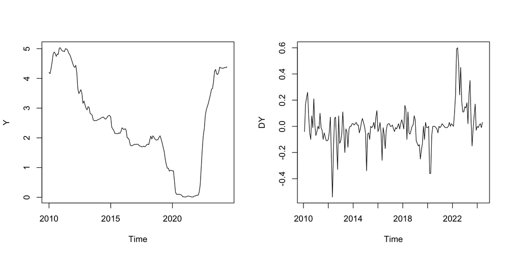

## ARMA(*p*,*q*) search

AICc proportion of (absolute) maximum:

```
      q=0   q=1   q=2   q=3   q=4
p=0 0.691 0.931 0.962 0.960 0.968
p=1 0.987 0.981 1.000 0.993 0.988
p=2 0.980 0.976 0.992 0.995 0.986
p=3 0.994 0.995 0.987 0.979 0.980
p=4 0.993 0.987 0.986 0.979 0.971
p=5 0.985 0.979 0.979 0.971 0.962
p=6 0.978 0.972 0.978 0.972 0.971
p=7 0.970 0.968 0.962 0.956 0.961
p=8 0.970 0.964 0.957 0.962 0.951
```

## ARMA(1,2) model

```
      ar1       ma1       ma2 intercept
    0.904    -0.305    -0.310     0.004
```

$$\begin{align}
Y_t &= 0.004 + Z_t \\
Z_t &= 0.904 Z_{t-1} + U_t
-0.305 U_{t-1}
-0.310 U_{t-2}
\end{align}$$

## AR(3) model

```
      ar1       ar2       ar3 intercept
    0.639    -0.153     0.183     0.002
```

$$\begin{align}
Y_t &= 0.002 + Z_t \\
Z_t &= 0.639 Z_{t-1}
-0.153 Z_{t-2}
+ 0.183 Z_{t-3}
+ U_t
\end{align}$$

## Forecasts

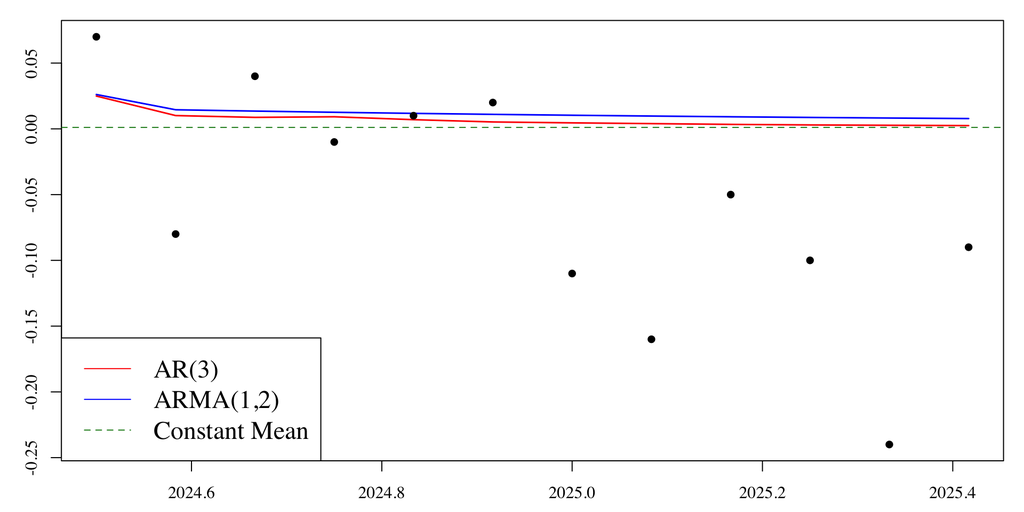

## Forecasts

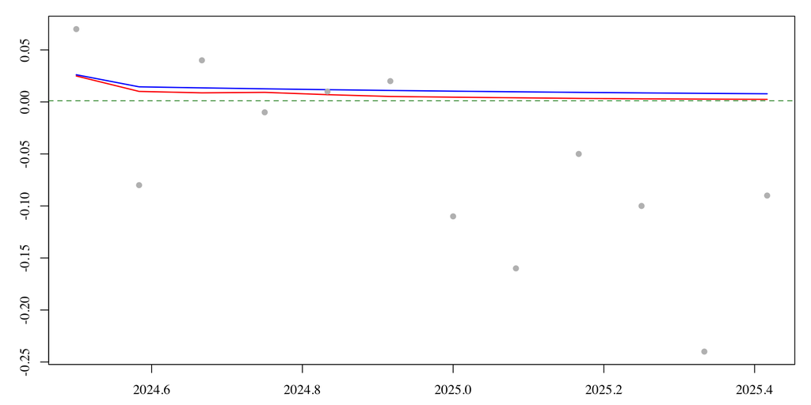

${\color{magenta}{\text{Why such similar forecasts?}}}$

## Inverting an MA(1) Model

Write  
$\qquad Z_t = U_t + \theta_1 \ U_{t-1}$  
as  
$\qquad U_t = - \theta_1\ U_{t-1} + Z_t$

## Inverting an MA(1) Model

Write  
$\qquad Z_t = U_t + \theta_1 \ U_{t-1}$  
as  
$\qquad U_t = - \theta_1\ {\color{cyan}{U_{t-1}}} + Z_t$

$\qquad\qquad\qquad{\color{cyan}{U_{t-1} = -\theta_1\ U_{t-2} + Z_{t-1}}}$

## Inverting an MA(1) Model

Write  
$\qquad Z_t = U_t + \theta_1 \ U_{t-1}$  
as  
$\qquad U_t = - \theta_1\ {\color{cyan}{(-\theta_1\ U_{t-2} + Z_{t-1})}} + Z_t$

## Inverting an MA(1) Model

Write  
$\qquad Z_t = U_t + \theta_1 \ U_{t-1}$  
as  
$\qquad U_t = - \theta_1\ (-\theta_1\ U_{t-2} + Z_{t-1}) + Z_t$  
$\qquad \phantom{U_t} = \theta_1^2\ U_{t-2} - \theta_1 \ Z_{t-1} + Z_t$

## Inverting an MA(1) Model

Write  
$\qquad Z_t = U_t + \theta_1 \ U_{t-1}$  
as  
$\qquad U_t = \theta_1^2\ U_{t-2} - \theta_1 \ Z_{t-1} + Z_t$

## Inverting an MA(1) Model

Write  
$\qquad Z_t = U_t + \theta_1 \ U_{t-1}$  
as  
$\qquad U_t = \theta_1^2\ {\color{cyan}{U_{t-2}}} - \theta_1 \ Z_{t-1} + Z_t$

$\qquad\qquad\qquad{\color{cyan}{U_{t-2} = -\theta_1\ U_{t-3} + Z_{t-2}}}$

## Inverting an MA(1) Model

Write  
$\qquad Z_t = U_t + \theta_1 \ U_{t-1}$  
as  
$\qquad U_t = \theta_1^2\ {\color{cyan}{(-\theta_1\ U_{t-3} + Z_{t-2})}} - \theta_1 \ Z_{t-1} + Z_t$

## Inverting an MA(1) Model

Write  
$\qquad Z_t = U_t + \theta_1 \ U_{t-1}$  
as  
$\qquad U_t = \theta_1^2\ (-\theta_1\ U_{t-3} + Z_{t-2}) - \theta_1 \ Z_{t-1} + Z_t$  
$\qquad \phantom{U_t} = -\theta_1^3 \ U_{t-3} + \theta_1^2\ Z_{t-2} - \theta_1 \ Z_{t-1} + Z_t$

## Inverting an MA(1) Model

Write  
$\qquad Z_t = U_t + \theta_1 \ U_{t-1}$  
as  
$\qquad U_t = -\theta_1^3 \ {\color{cyan}{U_{t-3}}} + \theta_1^2\ Z_{t-2} - \theta_1 \ Z_{t-1} + Z_t$

Continuing this process…

## Inverting an MA(1) Model

Write  
$\qquad Z_t = U_t + \theta_1 \ U_{t-1}$  
as  
$\qquad U_t = -\theta_1^3 \ U_{t-3} + \theta_1^2\ Z_{t-2} - \theta_1 \ Z_{t-1} + Z_t$  
$\qquad\qquad \vdots$  
$\qquad U_t = (-\theta_1)^t \ U_0 + (-\theta_1)^{t-1} Z_{1} + (-\theta_1)^{t-2} Z_{2} + \ldots$ $\qquad\qquad\qquad + \theta_1^2\ Z_{t-2} - \theta_1 \ Z_{t-1} + Z_t$

## Inverting an MA(1) Model

$\quad {\color{red}{U_t}} = {\color{yellow}{(-\theta_1)^t \ U_0}} + (-\theta_1)^{t-1} Z_{1} + {\color{violet}{(-\theta_1)^{t-2} Z_{2}}} + \ldots$ $\qquad\qquad\qquad {\color{orange}{-\theta_1^3 Z_{t-3}}} + {\color{lime}{\, \theta_1^2\ Z_{t-2}}} \, {\color{magenta}{ - \, \theta_1 Z_{t-1}}} + {\color{cyan}{Z_t}}$

Solve for $Z_t :$
$$\begin{align}
{\color{cyan}{Z_t}} &= {\color{magenta}{\theta_1 Z_{t-1}}}
{\color{lime}{- \, \theta_1^2 Z_{t-2}}}
+ {\color{orange}{\theta_1^3 Z_{t-3}}} + \ldots \qquad\qquad \\
& \qquad - {\color{violet}{(-\theta_1)^{t-2} Z_2}} - (-\theta_1)^{t-1} Z_1 \\
& \qquad - {\color{yellow}{(-\theta_1)^{t} U_0}} + {\color{red}{U_t}}
\end{align}$$

## Inverting an MA(1) Model

$$Z_t = U_t + \theta_1 U_{t-1}$$

can be written

$$Z_t = -\sum_{j=1}^{t-1} \, (-\theta_1)^j \, Z_{t-j} + U_t
- (-\theta_1)^t U_0$$

## Inverting an MA(1) Model

$$Z_t = -\sum_{j=1}^{t-1} {\color{orange}{(-\theta_1)^j}} \, Z_{t-j} + U_t
- {\color{orange}{(-\theta_1)^t}} U_0$$

If ${\color{orange}{|\theta_1|<1}}$ then ${\color{orange}{(-\theta_1)^j}} \rightarrow 0$ as $j$ increases.

## Autoregressive approximation

$$Z_t = \sum_{j=1}^{{\color{magenta}{t-1}}}
{\color{orange}{-(-\theta_1)^j}} \, Z_{t-j} + U_t
- {\color{orange}{(-\theta_1)^t}} {\color{magenta}{U_0}}$$

If ${\color{orange}{|\theta_1|<1}}$ then ${\color{orange}{(-\theta_1)^j}} \rightarrow 0$ as $j$ increases.

$$Z_t \: {\color{magenta}{\large\approx}}
\sum_{j=1}^{\color{magenta}{p}}
{\color{orange}{\phi_j}} \, Z_{t-j} + U_t$$

If $p$ is “large enough” then the autoregressive approximation “works well”.

## Autoregressive approximation

```r
Y <- arima.sim(n=800, list(ma=-0.5))
```

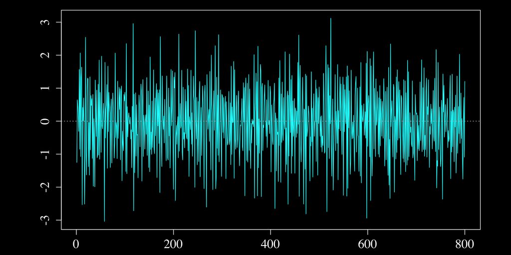

## Autoregressive approximation

```r
MA1 <- Arima(Y, order=c(0,0,1))
```

```
      ma1 intercept
  -0.5013   -0.0261
```

## Autoregressive approximation

```
      ma1 intercept
  -0.5013   -0.0261
```

${\color{magenta}{\widehat{\theta}_1 = -0.5013}}$

$\qquad\quad {\color{cyan}{Z_t = \displaystyle\sum_{j=1}^{t-1} -(-\theta_1)^j \, Z_{t-j} + U_t - (-\theta_1)^t U_0}}$

## Autoregressive approximation

```
      ma1 intercept
  -0.5013   -0.0261
```

${\color{magenta}{\widehat{\theta}_1 = -0.5013}}$

$\qquad\quad Z_t = \displaystyle\sum_{j=1}^{t-1} {\color{magenta}{-(-\theta_1)^j}} \, Z_{t-j} + U_t - (-\theta_1)^t U_0$

```
           j -(-ma1)^j
           1    -0.501
           2    -0.251
           3    -0.126
           4    -0.063
           5    -0.032
           6    -0.016
           7    -0.008
           8    -0.004
```

## Autoregressive approximation: coefficients

```
    j -(-ma1)^j   AR1    AR2    AR3    AR4
    1    -0.501 -0.39 -0.464 -0.488 -0.497
    2    -0.251       -0.191 -0.249 -0.266
    3    -0.126              -0.126 -0.159
    4    -0.063                     -0.070
    5    -0.032
    6    -0.016
    7    -0.008
    8    -0.004
    9    -0.002
   10    -0.001
   11    -0.001
   12     0.000
```

## Autoregressive approximation: coefficients

```
    j -(-ma1)^j    AR5    AR6    AR7    AR8
    1    -0.501 -0.492 -0.491 -0.492 -0.494
    2    -0.251 -0.255 -0.255 -0.250 -0.251
    3    -0.126 -0.141 -0.142 -0.145 -0.143
    4    -0.063 -0.035 -0.037 -0.047 -0.049
    5    -0.032  0.070  0.067  0.048  0.043
    6    -0.016        -0.007 -0.044 -0.051
    7    -0.008               -0.073 -0.088
    8    -0.004                      -0.030
    9    -0.002
   10    -0.001
   11    -0.001
   12     0.000
```

## Autoregressive approximation: forecasts

```
    h    MA1    AR1    AR2    AR3    AR4
    1 -0.397 -0.506 -0.394 -0.456 -0.471
    2 -0.026  0.161 -0.090  0.011 -0.015
    3 -0.026 -0.099  0.074 -0.092 -0.035
    4 -0.026  0.002 -0.060  0.051 -0.039
    5 -0.026 -0.037 -0.029 -0.052  0.012
    6 -0.026 -0.022 -0.018 -0.024 -0.041
    7 -0.026 -0.028 -0.029 -0.030 -0.026
    8 -0.026 -0.025 -0.026 -0.021 -0.027
    9 -0.026 -0.026 -0.025 -0.028 -0.026
   10 -0.026 -0.026 -0.026 -0.026 -0.025
   11 -0.026 -0.026 -0.026 -0.026 -0.027
   12 -0.026 -0.026 -0.026 -0.026 -0.026
```

## Autoregressive approximation: forecasts

```
    h    MA1    AR5    AR6    AR7    AR8
    1 -0.397 -0.586 -0.571 -0.515 -0.485
    2 -0.026  0.057  0.061  0.177  0.186
    3 -0.026 -0.008 -0.016  0.032  0.079
    4 -0.026 -0.095 -0.098 -0.173 -0.154
    5 -0.026  0.097  0.104  0.076  0.046
    6 -0.026 -0.114 -0.122 -0.057 -0.067
    7 -0.026  0.000  0.007 -0.077 -0.055
    8 -0.026 -0.031 -0.034  0.028 -0.009
    9 -0.026 -0.028 -0.027 -0.065 -0.041
   10 -0.026 -0.016 -0.016 -0.005 -0.023
   11 -0.026 -0.037 -0.038 -0.028 -0.022
   12 -0.026 -0.021 -0.019 -0.036 -0.029
```

## Non-invertibility

Practically relevant is $\theta_1 = -1 :$  
$\qquad Z_t = U_t - U_{t-1}$

Why relevant? Suppose  
$\qquad Y_t=U_t$  
but we (mistakenly) take a first difference:  
$\qquad Z_t = \Delta Y_t = U_t-U_{t-1}$.

## Non-invertibility

Practically relevant is ${\color{orange}{\theta_1 = -1}} :$  
$\qquad Z_t = U_t - U_{t-1}$

Autoregressive “approximation”: $\qquad Z_t = \displaystyle \sum_{j=1}^{t-1} \ ({\color{orange}{-1}}) \ Z_{t-j} + U_t + ({\color{orange}{-1}}) \ U_0$

$\qquad\qquad {\color{orange}{\uparrow}}$  
${\color{orange}{\text{These coefficients do not}}}$  
${\color{orange}{\text{decline with } j}}$

AR(*p*) estimation is generally poor for any *p*.

## Autoregressive approximation: coefficients

```
    j -(-ma1)^j   AR1    AR2    AR3    AR4
    1        -1 -0.49 -0.649 -0.741 -0.813
    2        -1       -0.327 -0.508 -0.637
    3        -1              -0.280 -0.468
    4        -1                     -0.253
    5        -1
    6        -1
    7        -1
    8        -1
    9        -1
   10        -1
   11        -1
   12        -1
```

## Autoregressive approximation: coefficients

```
    j -(-ma1)^j    AR5    AR6    AR7    AR8
    1        -1 -0.835 -0.842 -0.856 -0.873
    2        -1 -0.678 -0.707 -0.730 -0.756
    3        -1 -0.523 -0.570 -0.627 -0.658
    4        -1 -0.323 -0.384 -0.469 -0.525
    5        -1 -0.086 -0.161 -0.266 -0.342
    6        -1        -0.090 -0.216 -0.304
    7        -1               -0.149 -0.252
    8        -1                      -0.120
    9        -1
   10        -1
   11        -1
   12        -1
```

## Autoregressive approximation: forecasts

```
    h   MA1    AR1    AR2    AR3    AR4
    1 -0.81 -0.845 -0.745 -1.065 -1.566
    2  0.00  0.413 -0.080  0.234  0.374
    3  0.00 -0.203  0.294 -0.116  0.175
    4  0.00  0.099 -0.166  0.263 -0.088
    5  0.00 -0.049  0.011 -0.204  0.178
    6  0.00  0.023  0.046  0.048 -0.269
    7  0.00 -0.012 -0.035 -0.008  0.098
    8  0.00  0.005  0.006  0.036  0.027
    9  0.00 -0.004  0.006 -0.039 -0.007
   10  0.00  0.001 -0.007  0.010  0.007
   11  0.00 -0.001  0.001  0.000 -0.042
   12  0.00  0.000  0.000  0.004  0.023
```

## Autoregressive approximation: forecasts

```
    h   MA1    AR5    AR6    AR7    AR8
    1 -0.81 -1.601 -1.516 -1.428 -1.232
    2  0.00  0.245  0.137  0.200  0.098
    3  0.00  0.234  0.101 -0.079 -0.031
    4  0.00  0.014  0.082 -0.137 -0.283
    5  0.00  0.068  0.186  0.306  0.143
    6  0.00 -0.134 -0.241 -0.032  0.079
    7  0.00 -0.042  0.096 -0.081  0.064
    8  0.00  0.062 -0.081  0.150  0.016
    9  0.00  0.020  0.040 -0.175  0.033
   10  0.00 -0.003  0.020  0.060 -0.098
   11  0.00 -0.022 -0.018 -0.022  0.014
   12  0.00 -0.010  0.011 -0.008 -0.023
```

$$\large{\textbf{Higher order models}}$$

## Lag operator

Define the “lag operator” ${\color{lime}{L}}:$
$${\color{lime}{L}} \ Y_{t} = Y_{t{\color{lime}{-1}}}$$

The lag operator can be applied multiple times:
$$\begin{align}
L^2\, Y_t = L \, {\color{cyan}{L\, Y_t}}
= L\, {\color{cyan}{Y_{t-1}}} = Y_{t-2}
\end{align}$$

## Lag operator

Define the “lag operator” ${\color{lime}{L}}:$
$${\color{lime}{L}} \ Y_{t} = Y_{t{\color{lime}{-1}}}$$

The lag operator can be applied multiple times:
$$\begin{align}
L^2\, Y_t &= L \, {\color{cyan}{L\, Y_t}}
= L\, {\color{cyan}{Y_{t-1}}} = Y_{t-2}
\\
L^{\color{magenta}{3}}\, Y_t &= Y_{t{\color{magenta}{-3}}}
\\
L^{\color{orange}{4}}\, Y_t &= Y_{t{\color{orange}{-4}}}
\\
\text{etc}
\end{align}$$

## Lag operator

Define the “lag operator” ${\color{lime}{L}}:$
$${\color{lime}{L}} \ Y_{t} = Y_{t{\color{lime}{-1}}}$$

The lag operator can be applied multiple times:
$$\begin{align}
L^{\color{magenta}{j}}\, Y_t &= Y_{t{\color{magenta}{-j}}} \\
\end{align}$$

$j$ could be negative, eg $L^{-1}Y_t=Y_{t+1}$.  
Negative lag is a “lead”.

## Difference operator

$$\Delta = 1-L$$

i.e. $\quad \Delta Y_t = (1-L) Y_t = Y_t-Y_{t-1}$.

## AR Models

AR(1):
$$\begin{align}
&{\color{orange}{Y_t}} = {\color{lime}{\phi_1 Y_{t-1}}} + U_t \\
\Rightarrow \quad &({\color{orange}{1}}{\color{lime}{\, - \, \phi_1L}}) \, Y_t = U_t
\end{align}$$

AR(*p*):
$$\begin{align}
& Y_t = \phi_1 Y_{t-1} + \phi_2 Y_{t-2} + \ldots + \phi_p Y_{t-p} + U_t \\
\Rightarrow \quad & (1-\phi_1L - \phi_2 L^2 - \ldots - \phi_p L^p) Y_t = U_t
\end{align}$$

## AR Models

AR(*p*):
$$\begin{align}
& Y_t = \phi_1 Y_{t-1} + \phi_2 Y_{t-2} + \ldots + \phi_p Y_{t-p} + U_t \\
\Rightarrow \quad &
{\color{cyan}{(1-\phi_1L - \phi_2 L^2 - \ldots - \phi_p L^p)}}
Y_t = U_t
\end{align}$$

$$\begin{array}{c}
{\color{cyan}{\uparrow}}\\
{\color{cyan}{\text{Lag polynomial of order } p}}
\end{array}$$

## MA Models

MA(*q*):
$$\begin{align}
& Y_t = U_t + \theta_1 U_{t-1} + \theta_2 U_{t-2} + \ldots
+ \theta_q U_{t-q} \\
\Rightarrow \quad &Y_t = (1+\: \theta_1L \quad
+ \: \theta_2L^2 \:\:\:+ \ldots
+\theta_q L^q \quad) \, U_t
\end{align}$$

## MA Models

MA(*q*):
$$\begin{align}
& Y_t = U_t + \theta_1 U_{t-1} + \theta_2 U_{t-2} + \ldots
+ \theta_q U_{t-q} \\
\Rightarrow \quad &{\color{cyan}{Y_t = (1+\: \theta_1L \quad
+ \: \theta_2L^2 \:\:\:+ \ldots
+\theta_q L^q \quad) \, U_t}}
\end{align}$$

$$\begin{array}{c}
{\color{cyan}{\uparrow}}\\
{\color{cyan}{\text{Lag polynomial of order } q}}
\end{array}$$

$${\large\textbf{Moving average invertibility}}$$

## Invertibility of MA(1)

$$Y_t = U_t + \theta_1 U_{t-1}$$
is invertible if $|\theta_1|<1$.

## Invertibility of MA(1)

$$Y_t = (1 + \theta_1 L) U_{t}$$
is invertible if $|\theta_1|<1$.

The root of the lag polynomial is the solution of  
$\qquad\qquad 1+\theta_1 {\color{orange}{z}} = 0 \quad \phantom{\text{i.e.} \:\: z = -\dfrac{1}{\theta_1}}$

## Invertibility of MA(1)

$$Y_t = (1 + \theta_1 L) U_{t}$$
is invertible if $|\theta_1|<1$.

The root of the lag polynomial is the solution of  
$\qquad\qquad 1+\theta_1 z = 0 \quad \text{i.e.} \:\: {\color{orange}{z}} = -\dfrac{1}{\theta_1}$

$\text{The } {\color{lime}{\text{inverse root}}} \text{ is } {\color{lime}{z^{-1}}} = -\theta_1$

The model is invertible if the inverse root ${\color{yellow}{z^{-1}}}$ of ${\color{yellow}{(1+\theta_1 L)}}$ satisfies ${\color{yellow}{|z^{-1}| < 1}}$.

## Invertibility of MA(*q*)

$$\begin{align}
& Y_t = U_t + \theta_1 U_{t-1} + \theta_2 U_{t-2} + \ldots
+ \theta_q U_{t-q} \\
\Rightarrow \quad &Y_t = (1+\: \theta_1L \quad
+ \: \theta_2L^2 \:\:\:+ \ldots
+\theta_q L^q \quad) \, U_t
\end{align}$$

## Invertibility of MA(*q*)

$$Y_t = {\color{cyan}{(1+ \theta_1 L + \theta_2L^2 + \ldots
+\theta_q L^q )}} \, U_t$$

The roots of the $q$-order polynomial satisfy
$${\color{cyan}{1 + \theta_1 z + \theta_2 z^2 + \ldots + \theta_1 z^q}} = 0.$$
A $q$-order polynomial has $q$ roots, $z_1,\ldots,z_q$.

## Invertibility of MA(*q*)

$$Y_t = {\color{cyan}{(1+ \theta_1 L + \theta_2L^2 + \ldots
+\theta_q L^q )}} \, U_t$$

The roots of the $q$-order polynomial satisfy
$${\color{cyan}{1 + \theta_1 z + \theta_2 z^2 + \ldots + \theta_1 z^q}} = 0.$$

The model is invertible if the inverse roots satisfy $|{\color{magenta}{z_j^{-1}}}|<1$ *for all* $j=1,\ldots,q$.

$z_j$ may be a *complex number*.  
$|z_j^{-1}|<1\:\:\Rightarrow\:\:$ “$z_j^{-1}$ is inside the unit circle”.

## Invertibility of MA(2)

$$Y_t = (1+\theta_1 L + \theta_2 L^2) \, U_t$$

The roots satisfy  
$\qquad\qquad 1+\theta_1 z + \theta_2 z^2 = 0$  
i.e. quadratic with two solutions.

$$\zeta_1, \zeta_2 = \frac{-\theta_1 \pm \sqrt{\theta_1-4\theta_2}}{2\theta_2}$$

## Invertibility of MA(2)

$$Y_t = (1+\theta_1 L + \theta_2 L^2) \, U_t$$

The roots satisfy  
$\qquad\qquad 1+\theta_1 z + \theta_2 z^2 = 0$  
i.e. quadratic with two solutions.

$$\zeta_1^{-1}, \zeta_2^{-1} = \frac{2\theta_2}{-\theta_1 \pm \sqrt{\theta_1-4\theta_2}}$$

Invertibility: $|\zeta_1^{-1}|$ and $|\zeta_2^{-1}|\, < \, 1$

## Invertibility of MA(2)

$$Y_t = (1+\theta_1 L + \theta_2 L^2) \, U_t$$

The roots satisfy  
$\qquad\qquad 1+\theta_1 z + \theta_2 z^2 = 0$  
$\qquad\qquad (1-\zeta_1^{-1} z)(1-\zeta_2^{-1} z) =0$

Example:  
$\qquad 1-0.6L-0.4L^2 = (1-L)(1+0.4L)$

## Invertibility of MA(2)

$$Y_t = (1+\theta_1 L + \theta_2 L^2) \, U_t$$

The roots satisfy  
$\qquad\qquad 1+\theta_1 z + \theta_2 z^2 = 0$  
$\qquad\qquad (1-\zeta_1^{-1} z)(1-\zeta_2^{-1} z) =0$

Example:  
$\qquad 1-0.6L-0.4L^2 = (1-{\color{magenta}{1}}L)(1-{\color{lime}{(- 0.4)}}L)$

$\qquad\qquad\quad\:\:\: \zeta_1^{-1}, \zeta_2^{-1} = {\color{magenta}{1}}, {\color{lime}{-0.4}}$

Not invertible

## Invertibility of MA(2): Illustration

```r
set.seed(42)
Y <- arima.sim(n=400, list(ma=c(0.5,0.3)))
```

True model:
$$\begin{align}
Y_t &= U_t + 0.5 U_{t-1} + 0.3 U_{t-2} \\
&= (\, 1 + 0.5\,L\: + 0.3\, L^2\:) \, U_t
\end{align}$$

## Invertibility of MA(2): Illustration

```r
set.seed(42)
Y <- arima.sim(n=400, list(ma=c(0.5,0.3)))
MA2 <- Arima(Y, order=c(0,0,2))
print(round(MA2$coef,4))
```

```
      ma1       ma2 intercept
   0.4924    0.2545   -0.0156
```

## Invertibility of MA(2): Illustration

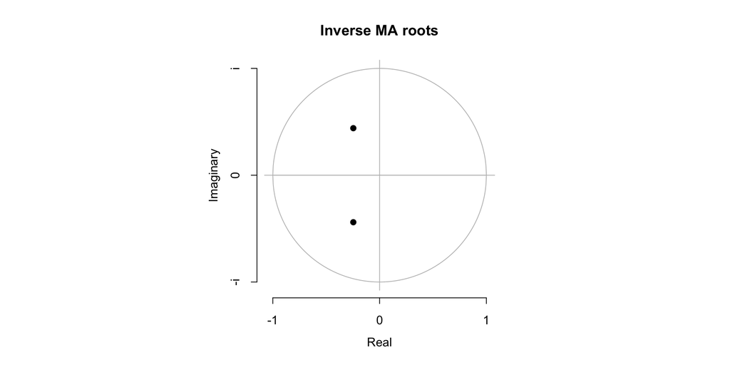

```r
set.seed(42)
Y <- arima.sim(n=400, list(ma=c(0.5,0.3)))
MA2 <- Arima(Y, order=c(0,0,2))
plot(MA2)
```

## Invertibility of MA(2): Illustration

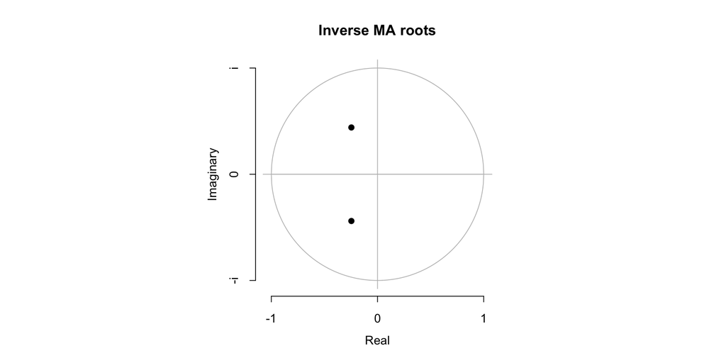

## Invertibility of MA(2): Illustration

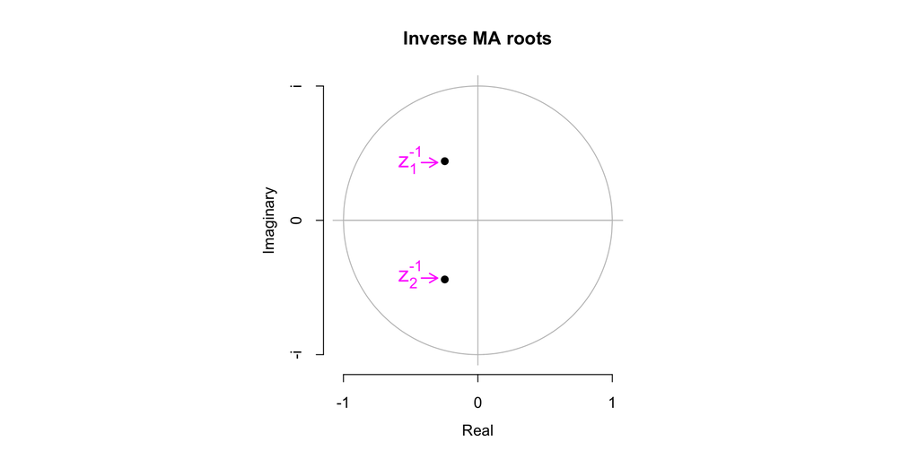

${\color{red}{\text{2 roots}}}$

${\color{green}{\text{Both are}}}$

${\color{green}{\text{complex}}}$

${\color{green}{\text{in this case.}}}$

## Invertibility of MA(2): Illustration

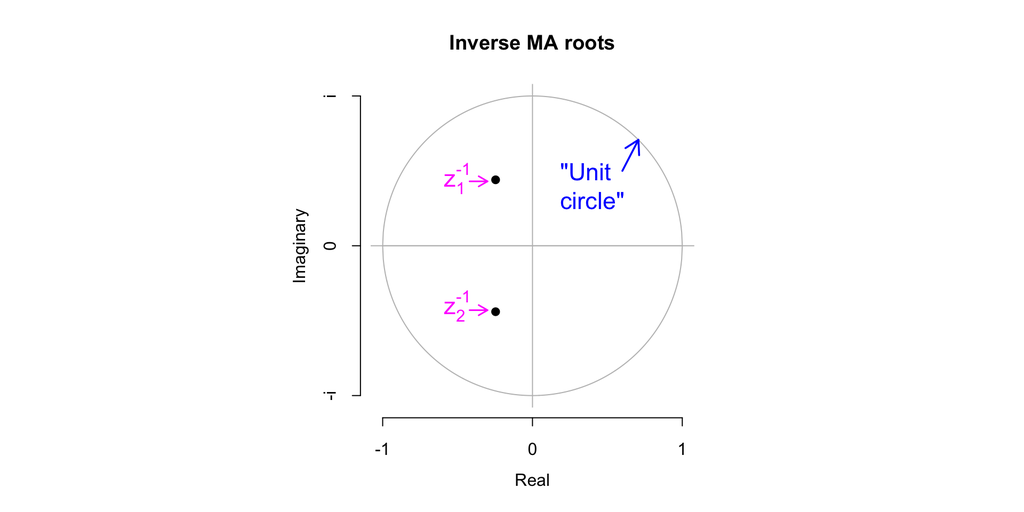

${\color{green}{\text{Inverse roots}}}$

${\color{green}{\text{are inside the}}}$

${\color{green}{\text{unit circle}}}$

${\color{green}{\quad \Downarrow\:}}$

${\color{green}{\text{this model is}}}$

${\color{green}{\text{invertible.}}}$

## Non-Invertibility of MA(2): Illustration

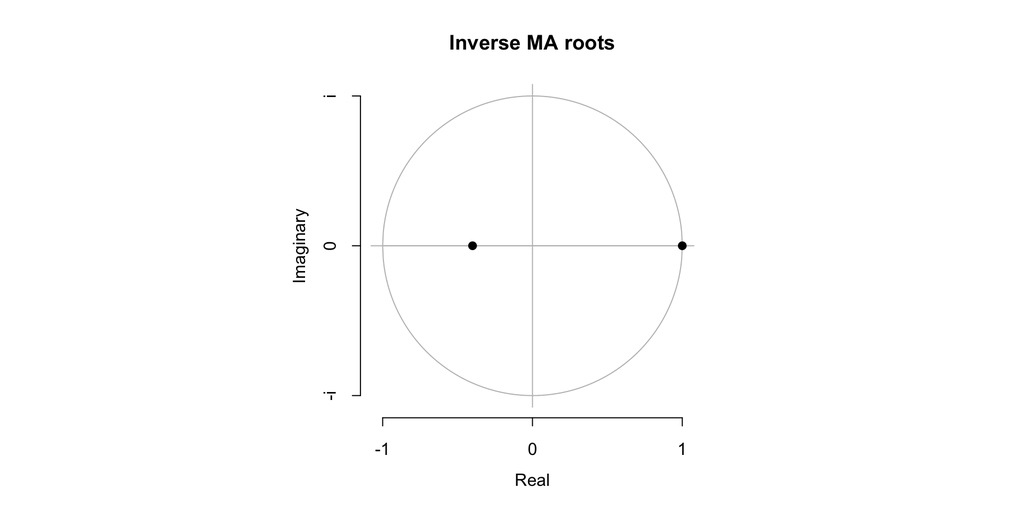

```r
set.seed(42)
Y <- arima.sim(n=400, list(ma=c(-0.6,-0.4)))
MA2 <- Arima(Y, order=c(0,0,2))
plot(MA2)
```

## Non-Invertibility of MA(2): Illustration

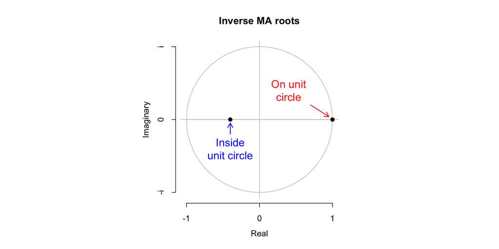

${\color{green}{\text{Both inverse}}}$

${\color{green}{\text{roots are real}}}$

${\color{green}{\text{(imaginary}}}$

${\color{green}{\text{ parts are zero)}}}$

## Non-Invertibility of MA(2): Illustration

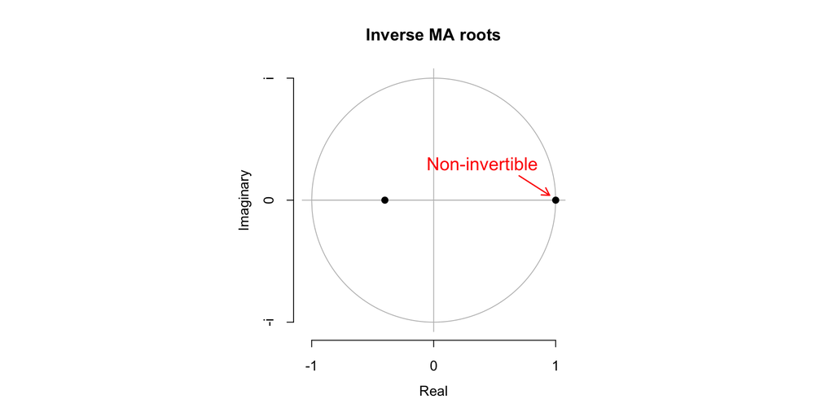

## Summary

- Invertible MA models can be approximated by AR models.
- AR models are more convenient, although more require more parameters.
- Invertibility is required for AR approximation.
- Invertibility is determined by the inverse roots of the MA lag polynomial.
- Be careful not to over-difference!